# DNN-IC

Codes by Tao Sun

Compiled by Kexin Liu, Yining Zu

2022/3/27

The DNN-IC model is a multi-layer deep neural network survival model to effectively extract features and make accurate and interpretable survival predictions for interval-censored data. To ensure high computational efficiency, the model is backed by Tensorflow and Keras. Various evaluation metrics, including time-dependent AUC and time-dependent Brier score, are also implemented to evaluate the prediction performance. To interpret the deep learning model, the subject-level feature importance measure is calculated and visualized using the novel Local Interpretable Model-Agnostic Explanation (LIME) algorithm. In this tutorial, we will illustrate and evaluate the DNN-IC model in one simulated interval-censored dataset.

# Installation

The first step is to install a version of TensorFlow on your system. The version used in this tutorial is the latest version 2.2.0. Note that on Windows, OS and Linux systems, Anaconda or miniconda installation is needed. Details can be found at [here](https://tensorflow.rstudio.com/installation/).

```r
install.packages("tensorflow")
library(tensorflow)
install_tensorflow(method = "conda")
```

You can confirm the installation is successful by:

```r
library(tensorflow)
tf$config$experimental_run_functions_eagerly(TRUE)
tf$constant("Hello Tensorflow")
```

```
## tf.Tensor(b'Hello Tensorflow', shape=(), dtype=string)
```

# Install Keras

DNN-IC uses the Keras API, which provides user friendly interface with Tensorflow.

```r
devtools::install_github("rstudio/keras")
library(keras)
install_keras(method = "conda")
```

```r
library(keras)
```

# Load utility functions (including loss function) and simulated data set

Multiple utility functions are needed for building and evaluating the model. The simulated interval-censored data is loaded for training.

```r
source("fun_DNN-IC.R")
load("interval_data.RData")
```

The datasets contains 1,000 subjects with variables including id, left, right, status (1 for left/interval-censoring, 0 for right-censoring), and 100 SNPs.

```r
dat = interval_data[,c("Left","Right","status",paste0("SNP_", 1:20))]
left_dat = as.matrix(dat[, c("Left")], nrow = nrow(dat))
right_dat = as.matrix(dat[, c("Right")], nrow = nrow(dat))
pred_dat = as.matrix(dat[, c(paste0("SNP_", 1:20))], nrow = nrow(dat))
status_dat = as.matrix(dat[, c("status")], nrow = nrow(dat))
right_dat[status_dat==0] = max(dat$Right[is.finite(dat$Right)]) + 0.1
```

# Model construction

The following chunk demonstrates the architecture of the neural network model in DNN-IC, which uses a sequential model that groups a linear stack of layers. The model include two chunks of layers: the predictor layers are to solve the predictors, and the time layers are to compute the baseline hazard for individuals. In the following example, the predictor layers contains four layers: an input layer, two hidden layers and an output layer. The hidden layers can be reduced to one. The time layers have two input layers and two output layers, and the hidden layer is a custom layer. In conclusion, there are three input layers, and the output layers are finally concatenated into one. Scaled Exponential Linear Unit (SeLU) is chosen as the activation function throughout the neural network (via string_activation). The L1 penalty is applied on the estimation of the weights in the network (via num_l1). The parameter num_lr controls the learning rate in the optimization process. The number of epoches (via num_epoch) determines the number of times that the DNN model processes the entire training samples. To enhance computational speed, samples are loaded into the model in batches, with the size of batch being controlled by the batch_size parameter. The key of the method is the customized loss function, which is previously loaded in fun_DNN-IC.R. The metrics are set to NULL because the AUC and Brier score will be calculated afterwards.

```r
# parameter setup
epoch <- 1000
batch_size <- 50
num_nodes <- 50
string_activation <- "selu"
num_l1 <- 0.1
num_dropout <- 0
num_lr <- 0.0002
num_layer <- 2
num_m = 3
num_l <- min(left_dat)
num_u <- max(right_dat)
```

```r
rm(model)
model <- build_model_ic(left_dat, right_dat, pred_dat, m = num_m, l = num_l, u = num_u, num_nodes, string_activation, num_l1, num_dropout, num_lr, num_layer)
```

```r
summary(model)
```

```
## Model: "model"
## ________________________________________________________________________________
##  Layer (type)             Output Shape      Param #  Connected to
## ================================================================================
##  pred (InputLayer)        [(None, 20)]      0        []
##
##  dense_2 (Dense)          (None, 50)        1050     ['pred[0][0]']
##
##  dropout_1 (Dropout)      (None, 50)        0        ['dense_2[0][0]']
##
##  dense_1 (Dense)          (None, 50)        2550     ['dropout_1[0][0]']
##
##  left (InputLayer)        [(None, 1)]       0        []
##
##  right (InputLayer)       [(None, 1)]       0        []
##
##  dropout (Dropout)        (None, 50)        0        ['dense_1[0][0]']
##
##  r_layer (RLayer)         (None, 1)         4        ['left[0][0]',
##                                                       'right[0][0]']
##
##  dense (Dense)            (None, 1)         51       ['dropout[0][0]']
##
##  concatenate (Concatenate  (None, 3)        0        ['r_layer[0][0]',
##  )                                                    'r_layer[1][0]',
##                                                       'dense[0][0]']
##
## ================================================================================
## Total params: 3,655
## Trainable params: 3,655
## Non-trainable params: 0
## ________________________________________________________________________________
```

# Run model

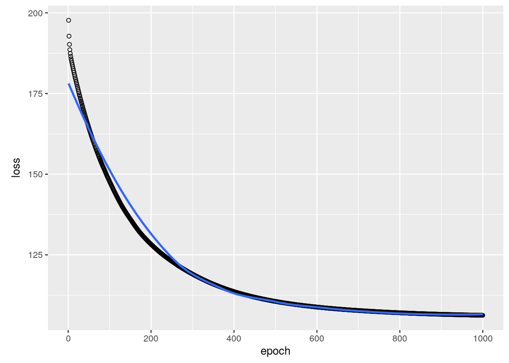

```r
history <- model %>% fit(
  list(left_dat, right_dat, pred_dat),
  status_dat,
  epochs = epoch,
  batch_size = batch_size,
  verbose = 1
)
plot(history)
```

# Evaluate prediction performance in test data using the time-dependent Brier score

The Brier score is essentially a prediction error metric. We offer both IBS and BS score, which can be chosen by “type”. In the following example, we calculated IBS, which can take all the time into consideration.

```r
### Brier score ###
brier <-  brier_ic_nn(obj = model,
                      left_new = left_dat,
                      right_new = right_dat,
                      x_new = pred_dat,
                      type = "IBS")
brier
```

```
##            [,1]
## [1,] 0.07914679
## attr(,"names")
## [1] "integrated Brier score"
## attr(,"time")
## [1]  0.25686 17.64455
```

# Evaluate prediction performance in test data using the time-dependent AUC

In survival prediction, we can obtain AUC values across time.

```r
### AUC ###
lp <- model %>% predict(list(left_dat, right_dat, pred_dat))
lp = lp[,3]
Marker = (lp - min(lp))/(max(lp) - min(lp)) + 0.1 # need to be positive
U <- as.vector(left_dat)
V <- as.vector(right_dat)
Delta <- 2 # 1 for LC, 2 for IC, 3 for RC
U <- ifelse(dat$Left == 0, V, U) # for left-censor
Delta <- ifelse(dat$Left == 0, 1, 2) # for left-censor
V <- ifelse(dat$Right == Inf, U, V) # for right-censor
Delta <- ifelse(dat$Right == Inf, 3, Delta) # for left-censor

library(intcensROC)
res <- intcensROC(U, V, Marker, Delta, median(U), gridNumber = 500)
intcensAUC(res)
```

```
## [1] 0.5875875
```

# LIME interpretation in test data: individual-level predictor importance

The Local Interpretable Model-agnostic Explanation (LIME) provides a prediction importance measure for each predictor in each subject by perturbing the predictor and evaluating how the prediction result changes. For the first time, we implement LIME to interpret importance under interval censoring.

```r
library("lime")
assignInNamespace("model_type.keras.engine.training.Model",model_type.keras.engine.training.Model,ns="lime")
assignInNamespace("predict_model.keras.engine.training.Model", predict_model.keras.engine.training.Model,ns="lime")


explainer <- lime(
  x              = data.frame(pred_dat),
  model          = model,
  bin_continuous = F)
```

```r
explanation <- lime::explain(
  x = data.frame(pred_dat),
  explainer    = explainer,
  n_features   = 10,
  feature_select = "auto",
  n_permutations = 1000)
```

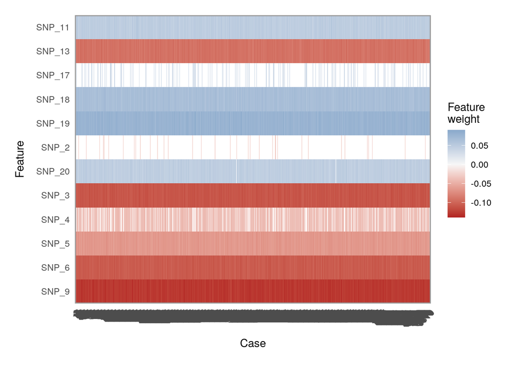

```r
plot_explanations(explanation)
```